# Permutation Test

### Background

In a previous analysis a study was conducted to determine if there exists a linear relationship between the number of computations and the amount of time it takes for a computer to compute it.

The analysis used a linear regression test but it was unfortunately inappropriate to run the test due to the failed assumptions. This analysis will use the same work used previously but a permutation test will be used instead.

The power of the permutation test is that no assumptions need to be satisfied. This will certainly be more appropriate than a linear regression test alone.

To find more information of the study, including the results of the linear regression, click on the link below.

Details of the linear regression analysis (click to view)

### Hypothesis

The analysis will only look at the slope of the linear line, therefore the hypothesis is written as thus,

$$H_0: \beta_1=0$$

$$H_a: \beta_1 \neq 0$$
$$\alpha = 0.05$$

### Analysis

Below is a graph taken from the original analysis. It shows a good linear line that follows most of the points except a few.

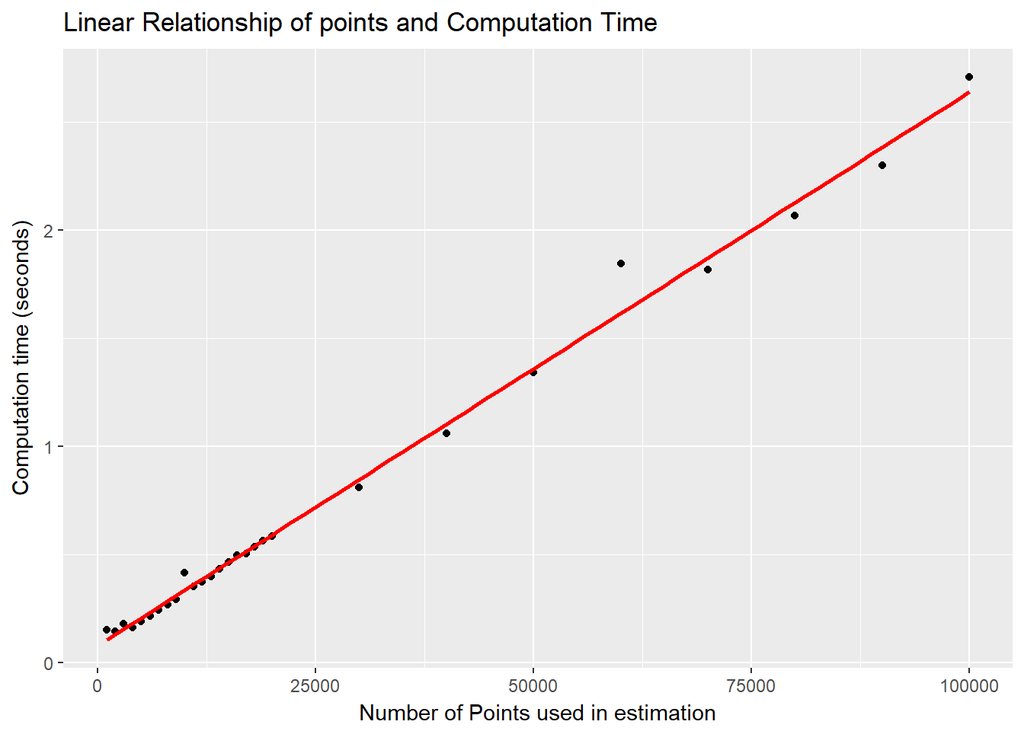

```r
ggplot(data = time, aes(x = points, y = comp.time)) +
  geom_point(color='black') +
  geom_smooth(method = "lm", se = FALSE, color="red") +
  xlab("Number of Points used in estimation") +
  ylab("Computation time (seconds)") +
  ggtitle("Linear Relationship of points and Computation Time")
```

A permutation test was conducted with 2,000 replications. A distribution of the 2,000 test statistics are shown in the histogram below.

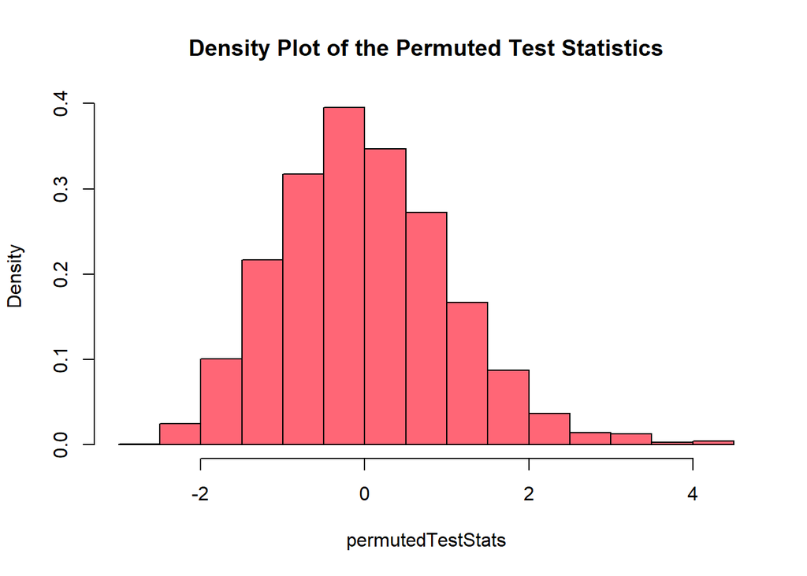

```r
set.seed(121)

# Finding the t of the linear regression test
myTest <- lm(comp.time ~ points, data = time)
observedTestStat <- summary(myTest)[[4]][2,3]

# re-creating 2000 t-scores
N <- 2000
permutedTestStats <- rep(NA, N)
for (i in 1:N){
  permutedData <- sample(time$comp.time)
  permutedTest <- lm(permutedData ~ points, data = time)
  permutedTestStats[i] <- summary(permutedTest)[[4]][2,3]
}

# Here the histogram of the distribution of the test statistics
hist(permutedTestStats, col=rgb(1,0,.1, .6), freq = FALSE, main="Density Plot of the Permuted Test Statistics")
abline(v = observedTestStat, col = "red", lwd = 3)
```

The test statistic from the non-permuted data produced a t-score of 65.44. Considering the test statistic was so high the p-value is less than 0.05. Thus the null hypothesis can be safely **rejected** and **conclude with the alternative hypothesis**.

### Interpretation

The permutation test was successful in answering the question as to whether $\beta_1 = 0$. The results of the study show that the $\beta_1 \neq 0$. There is a linear relationship between the number of points used in the program and the amount it takes to compute it. The results from the previous work show that the estimated slope is 2.56e-05. In other words, for every increase in 100,000 points the computation time is expected to increase by 2.56 seconds.

The distribution of the density plot is right skewed. This could be because of the small smample size used. One way to achieve a more normal distribution is to increase the sample size.

Source

J. Jashinsky, Simple Linear Regression, (11/2017)